# Analyzing Flight Delays

Team 2slow2furious: Justin Cole, Mark Grobaker, and Yoni Steinberg

March 10, 2017

### Introduction

Between 2007-2016, the U.S. Department of Transportation’s (DOT) Bureau of Transportation Statistics found that flights across the entire system were, on average, delayed 20% of the time. DOT defines “on time” as any flight that arrives within 15 minutes of schedule.

A research group at the National Center for Excellence for Aviation Operations Research (NEXTOR) found that, in 2007 alone, the total cost of flight delays was $32.9 billion, of which more than half of the total cost ($16.7 billion) was borne by passengers. This number was calculated based on lost passenger time due to flight delays, cancellations and missed connections, as well as expenses for food and accommodations as a result of being away from home.

So we began to ask the question: What if we could reliably predict flight delays and communicate that information to passengers? We decided not to attempt to change the total number of delays (i.e. by designing a system that could alert particular airlines to increase their resources if a flight was at-risk of being delayed) as we did not feel like the incentives are properly aligned to encourage airlines to change their behaviors.

However, we instead directed our efforts at gaining back some of that $16.7 billion that is stolen from passengers (ourselves included) each year. This is based on the assumption that if our predictions are accurate enough, we may be able to change some customers’ behaviors (this could be as simple as encouraging people to bring their own food so that they are not stuck having to purchase overpriced meals in the case of their flight being delayed or be prepared to call their airline to reschedule a connection if they have a short layover).

We decided to deliver this prediction through the creation of an iPhone and Android app that would allow people to input their flight number at any time and get the historic flight delay likelihood for that flight number. Additionally, because we anticipate that there is a “cascading” effect of delays, we would have a “real-time” option that would allow users to receive an automated text message 2 hours before the flight departs that would provide them an updated prediction, using information about the flight delay status of other flights on that day.

For the purposes of the beta version, we would predict potential flight delays only for those people on flights who are departing from Pittsburgh airport.

## Choosing the Outcome Variable

To begin our prediction, we began with an initial dataset of all flights departing and arriving at Pittsburgh airport in the year 2006, which consisted of 94,944 observations and 59 variables.

The dataset included a number of potential outcome variables, including continuous variables indicating the actual delay (in minutes) as well as a number of binary variables for whether the flight was delayed by a certain amount (for instance, if it was delayed by 15 or 30 minutes).

Given that we are predicting delays only for those people on flights who are departing from Pittsburgh airport, we first subset the data to only include those flights whose origin was Pittsburgh airport, which left us with 47,455 observations.

For choosing the outcome variable, we decided to select DepDel15, a binary variable that is “1” if a departure is delayed more than 15 minutes and “0” if a departure is delayed fewer than 15 minutes. We used this variable because it aligned with the DOT’s definition of “delayed.”

## Intuition About Variable Selection

Our intuition before beginning variable selection was that a number of variables would be good predictors of flight delays, including the carrier (we expected budget airlines to experience greater delays), the day of the week (we expected flights on high-travel days like Friday and Sunday to experience greater delays), the month (we expected flights in the winter to experience greater delays), the departure time block (we expected evening flights to be more delayed), and the destination (we expected high-volume airports, like NYC’s JFK and LGA and Chicago’s ORD, to experience greater delays).

## 1. Data Summary & Problem

```r
#load packages
library(plyr)
library(dplyr)
```

```r
library(ggplot2)
library(reshape2)
library(MASS)
library(partykit)
library(caret)
library(rpart)
library(randomForest)
library(pROC)
library(tree)
library(partykit)
library(gbm)
library(tidyr)
library(gridExtra)
library(glmnet)
#read in the data
all.flight.data <- read.csv("all_PIT_2006.csv")
```

2016.data

```r
new.flight.data <- read.csv("2016.flight.data.csv")
summary(new.flight.data$carrier)
```

```
##     AA     AS     B6     DL     EV     F9     HA     NK     OO     UA
##  75580  14205  23018  69711  41970   7099   6279  11047  47619  39761
##     VX     WN
##   5384 104154
```

```r
#change carrier code to carrier name
new.flight.data <- transform(new.flight.data, carrier = as.factor(mapvalues(carrier, from = c('AA', 'AS','B6', 'DL', 'EV', 'F9', 'OO', 'UA', 'WN'),  to = c('American','Alaska', 'Jetblue', 'Delta', 'ExpressJet', 'Frontier', 'SkyWest', 'United', 'Southwest'))))
```

## Incorporating New Variables

After examining variables in the initial data set, we reasoned that there may be additional variables that were not included in the original dataset that would be helpful in the prediction task.

We also constructed a new variable called “Delays so Far Today” that uses the Departure Time Block and looks at the count of the number of flights that have been delayed from the beginning of that day up to a point that is 2 hours before the flight departs (this is to ensure that we are able to provide information to the app user with enough time for them to be able to change their behavior, if desired).

There were a number of other variables that we also created using derivatives of the existing variables, such as:

- Airport.Region = used Destination airport’s city and state and then assigned that Destination to the proper geographic region (Midwest, Northeast, etc.)
- NumDelaysYest = Aggregated the total number of departure delays at Pittsburgh airport the previous day
- NumFlightsToday = Aggregated the total number of flights departing from Pittsburgh airport that day
- NumFlightsToDest = Aggregated the total number of flights that travel to that destination over the entire year of 2006
- Is.Weekend = Used the DayofWeek variable and coded all values of 6 and 7 as TRUE
- Is.Holiday = Used the Date variable to cross-reference the date with all Federal holidays (excluding Columbus Day and Veterans Day), with +- 1 day, and coded all as Holiday.

## Removing Variables

The largest chunk of time spent on this project was undoubtedly feature engineering. We first went through all 59 variables and, using the data dictionary available on the DOT’s Bureau of Transportation Statistics website, characterized the variable type, expected importance, range of values, and definition of each variable. While this process was time-consuming, it helped us to quickly identify variables in 3 broad categories that we did not need. The first category included variables that were duplicative or unnecessary, such as UniqueCarrier and Carrier, as they were equivalent to AirlineID. This grouping also included variables that were made unecessary due to the response variable that we selected (DepDel15), such as DepDel30, DepDelSys15, and ArrDel15. The second category included a number of other variables that were derivations of other variables, such as CRSDepTime and TaxiOut. The final category were variables that are only observed after the flight departs and therefore should not be included in the prediction itself, such as ActualElapsedTime, WheelsOn, CarrierDelay, etc.

```r
#limit to departing flights only
flight.data1 <- subset(all.flight.data, subset = Origin == 'PIT')

#get plane capacity
#read data
flight.capacity = read.csv("CapacityData.csv", header = TRUE)
#dedup by TailNum
cap.lookup = subset(flight.capacity, !duplicated(TailNum))
cap.lookup = cap.lookup[,c('TailNum','Capacity')]
#merge in data
flight.data1 = merge(flight.data1, cap.lookup, by='TailNum')
#create capacity groups
flight.data1 <- mutate(flight.data1, capacity.cat =
   cut(Capacity, breaks = c(-2, 0, 10, 55, 140, 200, 600),
       labels = c('unknown capacity','very low capacity',
                  'low capacity', 'medium capacity',
                  'high capacity', 'very high capacity')))

#read in airport.codes, which will be used later to get Airport.Region
airport.codes = read.csv("airport_codes.csv", header = TRUE)

#convert to date type
flight.data1$FlightDate = as.Date(flight.data1$FlightDate, format = "%m/%d/%Y")

#change carrier code to carrier name
flight.data1 <- transform(flight.data1, Carrier = as.factor(mapvalues(Carrier, from = c('B6','CO','DL', 'EV', 'FL', 'MQ', 'NW', 'OH', 'OO', 'RU', 'UA', 'US', 'WN', 'XE', 'YV'),  to = c('Jetblue', 'Continental', 'Delta', 'ExpressJet', 'Frontier', 'Simmons', 'Northwest', 'PSA', 'SkyWest', 'ExpressJet', 'United', 'USAir', 'Southwest', 'ExpressJet', 'Northwest'))))

#More feature engineering

#select columns of interest for model building
#select the columns from the data that we want to use
colnames2 <- c('FlightDate', 'Carrier', 'TailNum', 'Quarter', 'Month', 'DayofMonth', 'DayOfWeek', 'Distance', 'DistanceGroup', 'CRSElapsedTime', 'ArrTimeBlk', 'DepTimeBlk', 'Dest', 'DepDel15', 'capacity.cat')
flight.data2 <- subset(flight.data1, select = colnames2, subset = Origin == 'PIT')

#convert all columns to factors
flight.data2 = colwise(as.factor)(flight.data2)
#reset some columns to numeric
flight.data2$CRSElapsedTime =
  as.numeric(as.character(flight.data2$CRSElapsedTime))
flight.data2$Distance = as.numeric(as.character(flight.data2$Distance))
#reset some columns to Date
flight.data2$FlightDate = as.Date(flight.data1$FlightDate, format = "%m/%d/%Y")

#DestNumFlightsGroup. get number of flights by destination
DestNumFlights = ddply(flight.data2, "Dest", summarise, num.flights.to.dest = length(Dest))
DestNumFlights$num.flights.to.dest.group = cut_number(DestNumFlights$num.flights.to.dest, n=5, dig.lab=12)

#DestAvgDepDelayPct
DestAvgDepDelayPct = ddply(flight.data2, "Dest", summarise, dest.avg.delay.pct = sum(sum(DepDel15 == 1))/length(DepDel15))

#NumFlightsToday
NumFlightsToday = ddply(flight.data2, "FlightDate", summarise, num.flights.today = length(Dest))
#create bins
#NumFlightsToday$num.flights.today.group = cut_number(NumFlightsToday$num.flights.today, n=10)

#NumDelaysYest. (RStudio highlights this line red when it runs, but in fact it does not throw any error.)
NumDelaysYest = ddply(flight.data2, "FlightDate", summarise, num.delays.yest = sum(DepDel15 == 1))

#keep just a subset of the columns as NumDelaysToday
NumDelaysToday = subset(NumDelaysYest, select=c('FlightDate','num.delays.yest'))
#rename columns
colnames(NumDelaysToday) = c('FlightDate', 'num.delays.today')

#will use lead column when doing merge, so that we get previous day's delay
NumDelaysYest$FlightDateLead = NumDelaysYest$FlightDate + 1
#keep just a subset of the colums as NumDelaysYest
NumDelaysYest = subset(NumDelaysYest, select=c('FlightDateLead','num.delays.yest'))

#fill in the df with values for 1/1/2006, which is a special case
NumDelaysYest[nrow(NumDelaysYest)+1,"FlightDateLead"] =
  as.Date('1/1/2006', format="%m/%d/%Y")
#since we don't have delays for previous day, 12/31/2005,
#just set num.delays.yest equal to the average
NumDelaysYest[nrow(NumDelaysYest),"num.delays.yest"] =
  round(mean(NumDelaysYest$num.delays.yest, na.rm=T))

#NumDelaysSoFarToday
#sum up delays by date and time block
NumDelaysSoFarToday = ddply(flight.data2, c("FlightDate","DepTimeBlk"), summarise, num.delays.in.deptimeblock = sum(DepDel15 == 1))
#loop through to get delays so far today
for (i in 1:nrow(NumDelaysSoFarToday)) {
  #get the departure time blocks today
  deptimeblocks.today = subset(NumDelaysSoFarToday, subset = FlightDate == FlightDate[i])
  #subset to get just those deptimeblocks that are earlier today
  #we require the block to be at least two blocks previous to the current
  #eg if in 3-4 block, only count delays from 1-2 and before
  deptimeblocks.earlier.today = subset(deptimeblocks.today, subset = as.numeric(deptimeblocks.today$DepTimeBlk) <= as.numeric(NumDelaysSoFarToday$DepTimeBlk[i]) - 2)
  #take sum to get delays so far today
  NumDelaysSoFarToday$num.delays.so.far.today[i] =   sum(deptimeblocks.earlier.today$num.delays.in.deptimeblock)
}

#holidays
#list out all federal holidays, +/- 1 day, in 2006
#this includes: new years, mlk day, presidents day, memorial day
#independence day, labor day, thanksgiving, and christmas
#columbus day and veterans day are excluded
holidays <- c(
    '12/31/2006','1/1/2006','1/2/2006',
    '1/15/2006','1/16/2006','1/17/2006',
    '2/19/2006','2/20/2006','2/21/2006',
    '5/28/2006','5/29/2006','5/30/2006',
    '7/3/2006','7/4/2006','7/5/2006',
    '9/3/2006','9/4/2006','9/5/2006',
    '11/22/2006','11/23/2006','11/24/2006',
    '12/24/2006','12/25/2006','12/26/2006')
holidays = as.Date(holidays, format = '%m/%d/%Y')

#add Is.Holiday column
flight.data2 = mutate(flight.data2, Is.Holiday = FlightDate%in%holidays)
#add Is.Weekend column
flight.data2 = mutate(flight.data2, Is.Weekend = DayOfWeek%in%c(6,7))

#convert to factors
flight.data2$Is.Holiday <- as.factor(flight.data2$Is.Holiday)
flight.data2$Is.Weekend <- as.factor(flight.data2$Is.Weekend)
```

Merge data and prepare data set for model

```r
#create summary table by airport
DestSummary =
  merge(DestNumFlights, DestAvgDepDelayPct, by='Dest') %>%
  merge(airport.codes, by.x='Dest', by.y='Airport.Code')

#merge all created features with the main flights df
flight.data3 = merge(flight.data2, DestSummary, by='Dest')
flight.data3 = merge(flight.data3, NumDelaysSoFarToday,
                     by=c('FlightDate','DepTimeBlk'))
flight.data3 = merge(flight.data3, NumDelaysToday,
                     by.x='FlightDate', by.y='FlightDate', all.x=T)
flight.data3 = merge(flight.data3, NumDelaysYest,
                     by.x='FlightDate', by.y='FlightDateLead', all.x=T)
flight.data3 = merge(flight.data3, NumFlightsToday, by='FlightDate')

#export data for QC purposes
# write.table(flight.data3, "flight_data_3_export.csv", sep=',', row.names=F)
```

Select final data to be used in model

```r
#remove columns that will not be used in model
colnames4 <- colnames(flight.data3)[! colnames(flight.data3) %in% c('TailNum', 'Airport.City', 'num.delays.in.deptimeblock', 'num.delays.today', 'FlightDate',
'Dest', 'num.flights.to.dest.group')
  ]

flight.data4 <- subset(flight.data3, select = colnames4)
```

## Pre-Processing Data

As we performed basic descriptive statistics on our data, we found that the sample was significantly unbalanced, with only 18% of our values labeled as “delayed.” As a result, we tried upsampling our data in order to create additional observations of “delays” but we ultimately did not find that it helped our model’s performance and did not end up incorporating it into our final model.

Within each model we later ran, we performed the usual error estimates such as crossvalidation. However, for a final comparison of model results, it was also important to create a test set for comparison purposes.

We created a test and train data set by randomly sampling 1/8 of the observations and placing them into a test data set and keeping the remaining 7/8 of the observations in the training data set.

```r
#create train and test data set
test <- sample(1:nrow(flight.data4), nrow(flight.data4)/8)
flight.test <- flight.data4[test,]
flight.train <- flight.data4[-test,]

#actual class in test data (as numeric)
flight.obs <- as.numeric(as.character(flight.test$DepDel15))

#Upsample the training data to artifically overcome sample imbalance
flight.more.idx <- sample(which(flight.train$DepDel15 == "1"), 27000, replace = TRUE)
flight.train.upsampled <- rbind(flight.train,
                            flight.train[flight.more.idx, ])
table(flight.train.upsampled$DepDel15)
```

```
##
##     0     1
## 34182 34342
```

## Classification Performance Metrics

For reporting out classification performance metrics, we used the classMetrics formula that we created in Homework 5.

```r
classMetrics <- function(score, y, cutoff,
                         type = c("all", "accuracy", "sensitivity",
                                  "specificity", "ppv", "npv", "precision",
                                  "recall")) {
  type <- match.arg(type, several.ok = TRUE)
  n <- length(y)

  # Form confusion matrix
  score.factor <- factor(as.numeric(score >= cutoff), levels = c("0", "1"))
  confusion.mat <- table(score.factor, as.factor(y), dnn = list("predicted", "observed"))
  # Calculate all metrics
  acc <- sum(diag(confusion.mat)) / n
  sens <- confusion.mat[2,2] / sum(confusion.mat[,2])
  spec <- confusion.mat[1,1] / sum(confusion.mat[,1])
  ppv <- confusion.mat[2,2] / sum(confusion.mat[2,])
  npv <- confusion.mat[1,1] / sum(confusion.mat[1,])
  prec <- ppv
  rec <- sens

  metric.names <- c("accuracy", "sensitivity", "specificity",
                    "ppv", "npv", "precision", "recall")
  metric.vals <- c(acc, sens, spec, ppv, npv, prec, rec)

  # Form into data frame
  full.df <- data.frame(value = metric.vals)
  rownames(full.df) <- metric.names

  # Return just the requested subset of metrics
  if(type[1] == "all") {
    list(conf.mat = confusion.mat, perf = full.df)
  } else {
    list(conf.mat = confusion.mat,
         perf = subset(full.df, subset = metric.names %in% type))
  }
}
```

**Exploratory Data Analysis**

We were curious to see if there are any noteworthy patterns in our data that could be picked out visually before our models are built. We made four initial plots:

1. 2006 carrier count plot
2. Destination Frequency
3. %Delay by Airport
4. %Delays by Month

2006 carrier count plot

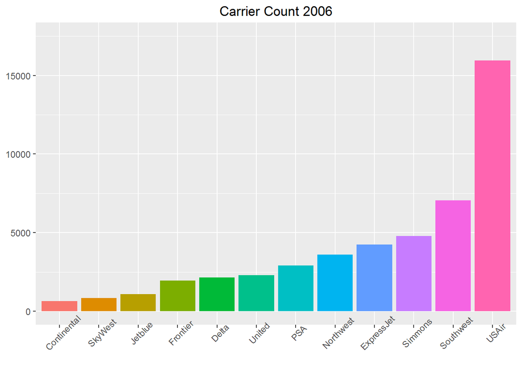

```r
flight.data.plot = ddply(flight.data4, "Carrier", summarise, count.flight = length(Carrier))

flight.data.plot1 <- transform(flight.data.plot, Carrier = reorder(Carrier, count.flight))

EDAcarrier.plot <- ggplot(flight.data.plot1, mapping = aes(x = Carrier, y = count.flight, fill = Carrier))

plot1.2006 <-EDAcarrier.plot + geom_bar(stat = "identity") + ggtitle("Carrier Count 2006") + theme(plot.title = element_text(hjust=0.5), axis.text.x = element_text(angle = 45), axis.title.x = element_blank(), axis.title.y = element_blank()) + ylim(0, 17500) + theme(legend.position="none")

plot1.2006
```

We see that USAir is the largest carrier, followed distantly by Southwest.

Destination Frequency

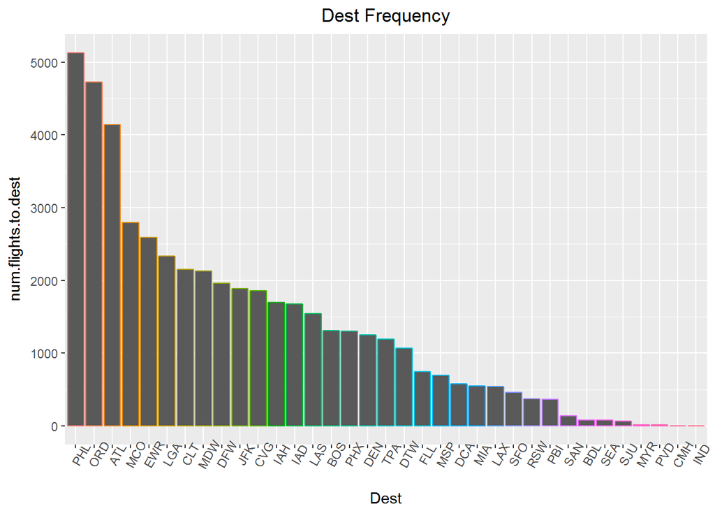

```r
flight.dest.plot <- DestSummary %>%
  group_by(Dest) %>%
  arrange(desc(num.flights.to.dest))

flight.dest.plot <- transform(flight.dest.plot, Dest = reorder(Dest, desc(as.numeric(num.flights.to.dest))))

ggplot(flight.dest.plot, mapping = aes(x = Dest, y = num.flights.to.dest, color = Dest)) + geom_bar(stat = "identity") + ggtitle("Dest Frequency") + theme(plot.title = element_text(hjust=0.5), axis.text.x = element_text(angle = 60)) + theme(legend.position="none")
```

The most-traveled to airports (from Pittsburgh) are Philadelphia, Chicago O’Hare, and Atlanta.

%Delay by Airport

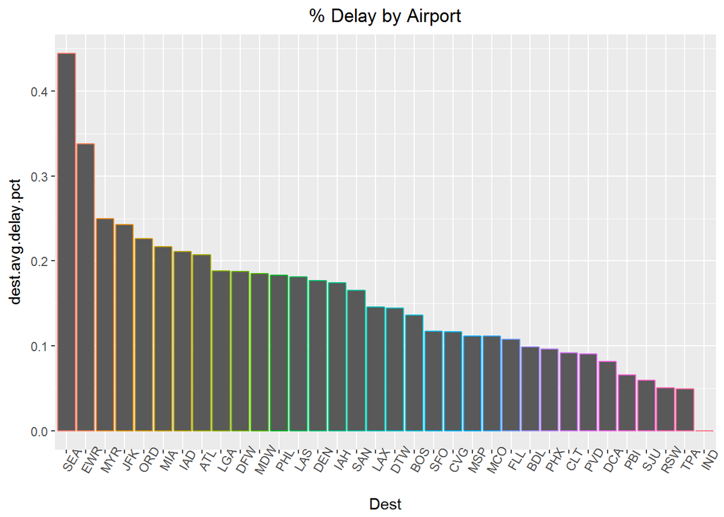

```r
flight.delay.plot <- DestSummary %>%
  filter(dest.avg.delay.pct < 1) %>%
  group_by(Dest) %>%
  arrange(desc(dest.avg.delay.pct))

flight.delay.plot <- transform(flight.delay.plot, Dest = reorder(Dest, desc(as.numeric(dest.avg.delay.pct))))

#% delay by airport
ggplot(flight.delay.plot, mapping = aes(x = Dest, y = dest.avg.delay.pct, color = Dest)) + geom_bar(stat = "identity") + ggtitle("% Delay by Airport") + theme(plot.title = element_text(hjust=0.5), axis.text.x = element_text(angle = 60)) + theme(legend.position="none")
```

Of the top five airport destinations with the highest delays, two are ones with very few flights: Seattle and Myrtle Beach. Newark (EWR), New York (JFK), and Chicago (ORD) are large destinations with high delay rates.

% Delays by month

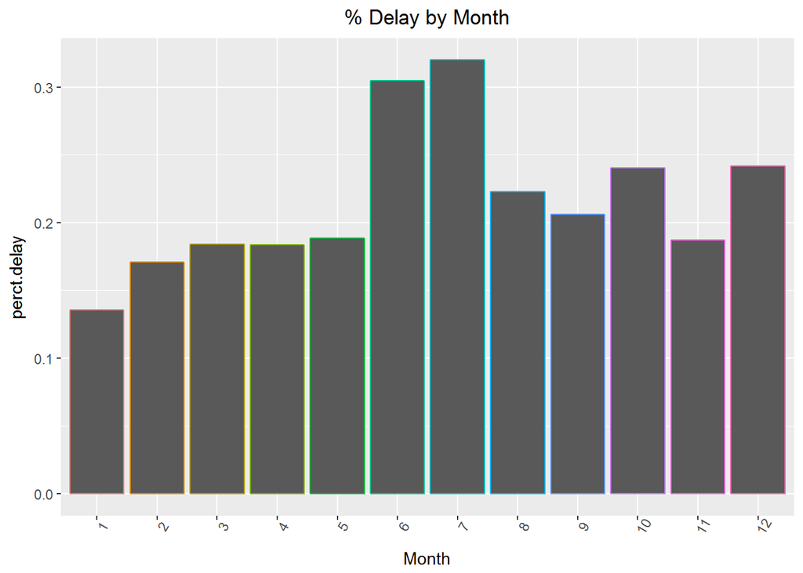

```r
delays.by.month = ddply(flight.data3, c("Month","DepDel15"), summarise, total.delayed = sum(DepDel15 == 1), total.ontime =sum(DepDel15==0))

delays.by.month.sub <- delays.by.month[,c(1,3,4)]

delay.melt <- reshape2::melt(delays.by.month.sub, id.vars = 'Month', measure.vars = c('total.delayed', 'total.ontime'))
delay.melt <- delay.melt %>%
  filter(value > 0)

delays.by.month.spread <- spread(delay.melt, key = variable, value = value)
delays.by.month.spread <- delays.by.month.spread %>%
  mutate(perct.delay = total.delayed/total.ontime)

ggplot(delays.by.month.spread, mapping = aes(x = Month, y = perct.delay, color = Month)) + geom_bar(stat = "identity") + ggtitle("% Delay by Month") + theme(plot.title = element_text(hjust=0.5), axis.text.x = element_text(angle = 60)) + theme(legend.position="none")
```

## Running the models

We ended up running five models for our classification task:

Regularized Logistic Regression: the pros are that it is interpretable and performs variable selection; however, the cons are that it is less flexible and assumes no interaction terms

Decision Tree: the pros are that it is highly interpretable; however, the cons are that it is highly variable and generally has poor classification accuracy

Random forests: the pros are that it is can capture interaction, which we believe to be important here, and it is highly flexible; however, the cons are that it produces results that are less interpretable

Bagging: similar tradeoffs as random forests

Boosting: similar tree-based ensemble method. Approach is different from bagging and RF, but the pros and cons are similar.

## Regularized Logistic Regression

For the regularized logistic regression, we first ran cross-validation on our data and then found our lambda that minimizes cross-validation error and then found the largest lambda within one standard error of the minimum. We then ran the lasso model and got predictions using the lambda that we found.

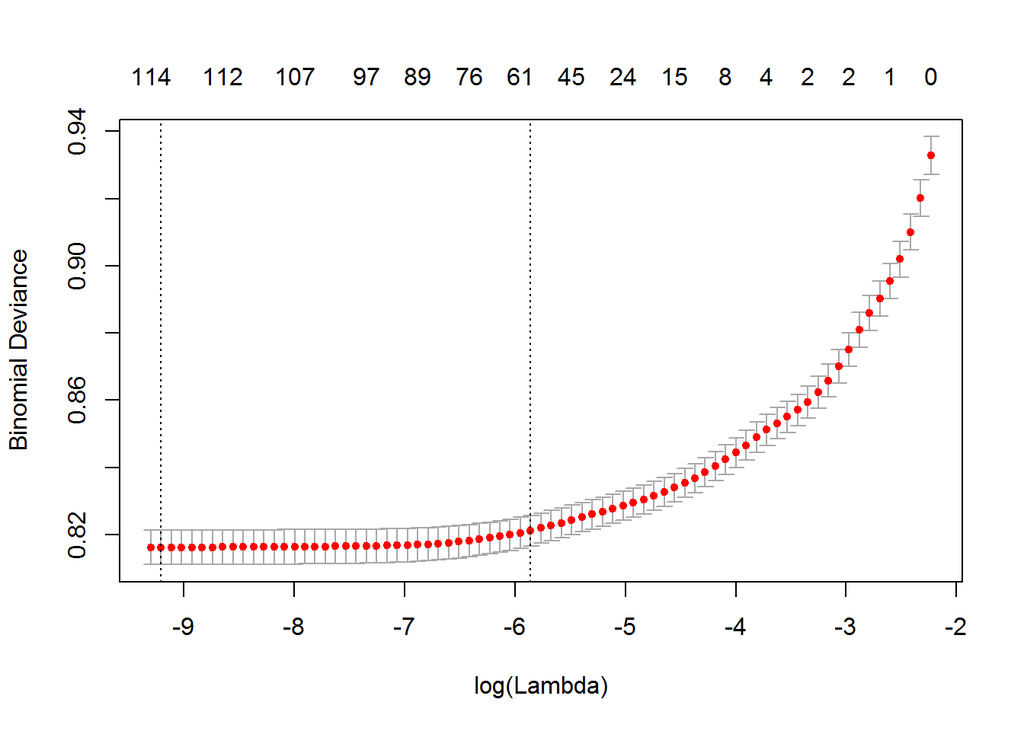

```r
#subset of training data, with outcome variable removed
#create sparse matrix
flight.train.pred = model.matrix(~., data = flight.train[,!(colnames(flight.train) == "DepDel15")])
#do same for test data
flight.test.pred = model.matrix(~., data = flight.test[,!(colnames(flight.test) == "DepDel15")])

#run crossvalidation
flight.lasso.cv <- cv.glmnet(x=flight.train.pred, y=flight.train$DepDel15, family="binomial")

plot(flight.lasso.cv)
```

```r
# Lambda min:
flight.lasso.cv$lambda.min
```

```
## [1] 0.0001002593
```

```r
# Lambda 1-SE
flight.lasso.cv$lambda.1se
```

```
## [1] 0.002855421
```

```r
# Index of the two lambdas
lambda.min.idx <- which(flight.lasso.cv$lambda == flight.lasso.cv$lambda.min)
lambda.1se.idx <- which(flight.lasso.cv$lambda == flight.lasso.cv$lambda.1se)

# Number of non-zero coefficients:
# Lambda min
flight.lasso.cv$nzero[lambda.min.idx]
```

```
## s75
## 114
```

```r
# Lambda 1-SE
flight.lasso.cv$nzero[lambda.1se.idx]
```

```
## s39
##  57
```

```r
#run lasso model
flight.lasso <- glmnet(x=flight.train.pred, flight.train$DepDel15, family="binomial")

#show the most important variables
flight.lasso.coef = coef(flight.lasso, s=flight.lasso.cv$lambda.1se)[,1]
#flight.lasso, s=flight.lasso.cv$lambda.1s
flight.lasso.coef = sort(flight.lasso.coef[flight.lasso.coef!=0])
flight.lasso.coef
```

```
##                    (Intercept)            DepTimeBlk2100-2159
##                  -3.322992e+00                  -8.855139e-01
##            DepTimeBlk0600-0659            DepTimeBlk0700-0759
##                  -8.015307e-01                  -3.454664e-01
##            ArrTimeBlk1000-1059            DepTimeBlk2000-2059
##                  -2.611439e-01                  -2.078466e-01
##                CarrierFrontier            ArrTimeBlk1100-1159
##                  -1.820093e-01                  -1.604325e-01
##            ArrTimeBlk0600-0659                   CarrierUSAir
##                  -1.595976e-01                  -1.355108e-01
##            DepTimeBlk0900-0959            DepTimeBlk0800-0859
##                  -9.844225e-02                  -9.690419e-02
##                     DayOfWeek2                     DayOfWeek6
##                  -8.678605e-02                  -6.138893e-02
##                    DayofMonth9                    DayofMonth6
##                  -4.836495e-02                  -4.531350e-02
##            ArrTimeBlk1300-1359                   CarrierDelta
##                  -3.595720e-02                  -2.463906e-02
##                     CarrierPSA                   DayofMonth10
##                  -2.389671e-02                  -1.833967e-02
##            ArrTimeBlk2000-2059                DistanceGroup10
##                  -1.652954e-02                  -1.735034e-03
##            num.flights.to.dest                 CRSElapsedTime
##                   2.184164e-05                   2.121463e-04
##              num.flights.today            DepTimeBlk1500-1559
##                   1.575170e-03                   2.875221e-03
##                   DayofMonth13                num.delays.yest
##                   3.707249e-03                   7.415055e-03
## capacity.catvery high capacity                    DayofMonth3
##                   2.645877e-02                   3.966867e-02
##            DepTimeBlk1700-1759        num.delays.so.far.today
##                   5.658020e-02                   6.044927e-02
##                     DayOfWeek5                     DayOfWeek4
##                   6.171848e-02                   6.255474e-02
##                   DayofMonth19                 DistanceGroup6
##                   9.098645e-02                   9.316187e-02
##            ArrTimeBlk1200-1259                    DayofMonth2
##                   1.009711e-01                   1.046078e-01
##            DepTimeBlk1900-1959                 CarrierSimmons
##                   1.052757e-01                   1.106446e-01
##              CarrierExpressJet    capacity.catmedium capacity
##                   1.140350e-01                   1.167934e-01
##               CarrierSouthwest            ArrTimeBlk2200-2259
##                   1.168491e-01                   1.246716e-01
##            DepTimeBlk1200-1259                         Month7
##                   1.263156e-01                   1.292047e-01
##                 DistanceGroup3                   DayofMonth22
##                   1.367961e-01                   1.551221e-01
##            ArrTimeBlk2100-2159                  CarrierUnited
##                   1.705645e-01                   1.929409e-01
##            DepTimeBlk1400-1459                         Month6
##                   1.931134e-01                   2.017552e-01
##            ArrTimeBlk1800-1859            ArrTimeBlk1700-1759
##                   2.506261e-01                   2.834844e-01
##       capacity.catlow capacity            ArrTimeBlk1600-1659
##                   2.834903e-01                   2.999601e-01
##            ArrTimeBlk2300-2359             dest.avg.delay.pct
##                   2.150803e+00                   3.946263e+00
```

We choose the 1SE lambda, shown on the graph above.

Variables with the most negative values contribute most to having on-time performance. We notice that (mostly) early departing flights are located here. On the other end, afternoon and evening departing flights are more likely to be late. The most predictive of delay is dest.avg.delay.pct. All of these results are somewhat intuitive, which is nice.

Note that since the intercept is around -3, the coefficients on the other variables may be greater than 1.

Here we see one of the major advantages of logistic regression: we are easily able to understand the output. We can see just how much each variable contributes to the probability of a late flight.

## Simple Decision Tree Model

```r
#create naive decision tree
flight.tree <- tree(DepDel15 ~ ., flight.train)
summary(flight.tree)
```

```
##
## Classification tree:
## tree(formula = DepDel15 ~ ., data = flight.train)
## Variables actually used in tree construction:
## [1] "num.delays.so.far.today" "dest.avg.delay.pct"
## Number of terminal nodes:  3
## Residual mean deviance:  0.861 = 35750 / 41520
## Misclassification error rate: 0.1768 = 7342 / 41524
```

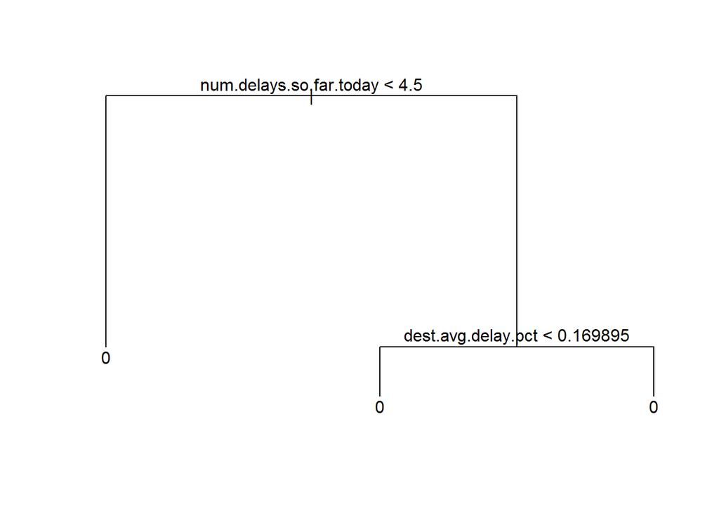

```r
#plot decision tree
plot(flight.tree)
text(flight.tree, pretty=0)
```

```r
print(flight.tree)
```

```
## node), split, n, deviance, yval, (yprob)
##       * denotes terminal node
##
## 1) root 41524 38740 0 ( 0.82319 0.17681 )
##   2) num.delays.so.far.today < 4.5 23286 14530 0 ( 0.90582 0.09418 ) *
##   3) num.delays.so.far.today > 4.5 18238 21710 0 ( 0.71768 0.28232 )
##     6) dest.avg.delay.pct < 0.169895 5411  4966 0 ( 0.82813 0.17187 ) *
##     7) dest.avg.delay.pct > 0.169895 12827 16250 0 ( 0.67108 0.32892 ) *
```

The tree shown above is small and does not need pruning. The tree only uses two variables, num.delays.so.far.today, and dest.avg.delay.pct. All leaves of the tree have a predicted class of 0 (given a cutoff of 0.5) but different class probabilities.

## Random Forest

```r
#run random forest
#for mtry we did the sqrt of the number of variables, and for ntree we looked at a test classification error plot that showed that at around 100 trees our classification error rate stayed flat
flight.rf <- randomForest(as.factor(DepDel15) ~ ., data = flight.train, mtry = 5, ntree=100,importance = T)
flight.rf
```

```
##
## Call:
##  randomForest(formula = as.factor(DepDel15) ~ ., data = flight.train,      mtry = 5, ntree = 100, importance = T)
##                Type of random forest: classification
##                      Number of trees: 100
## No. of variables tried at each split: 5
##
##         OOB estimate of  error rate: 16.59%
## Confusion matrix:
##       0    1 class.error
## 0 32474 1708  0.04996782
## 1  5182 2160  0.70580223
```

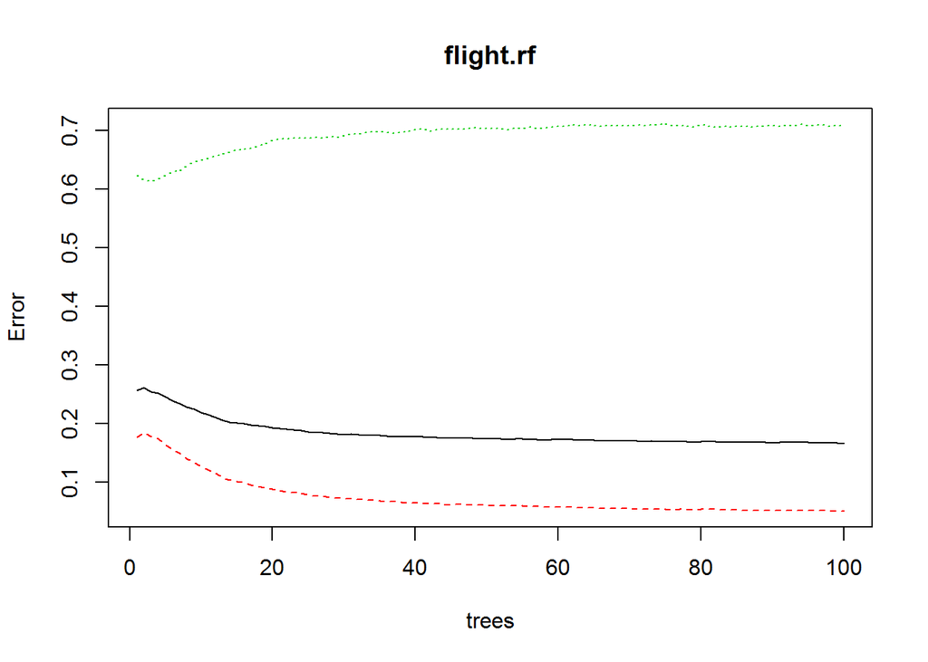

```r
plot(flight.rf)
```

```r
summary(flight.rf)
```

```
##                 Length Class  Mode
## call                6  -none- call
## type                1  -none- character
## predicted       41524  factor numeric
## err.rate          300  -none- numeric
## confusion           6  -none- numeric
## votes           83048  matrix numeric
## oob.times       41524  -none- numeric
## classes             2  -none- character
## importance         76  -none- numeric
## importanceSD       57  -none- numeric
## localImportance     0  -none- NULL
## proximity           0  -none- NULL
## ntree               1  -none- numeric
## mtry                1  -none- numeric
## forest             14  -none- list
## y               41524  factor numeric
## test                0  -none- NULL
## inbag               0  -none- NULL
## terms               3  terms  call
```

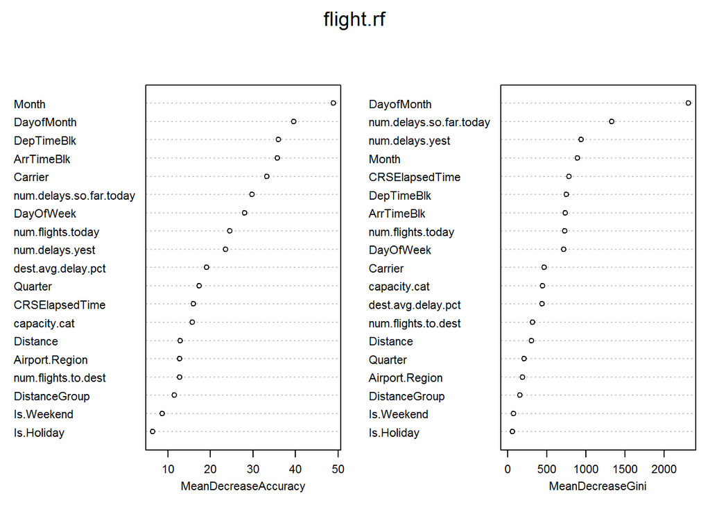

```r
varImpPlot(flight.rf, cex=0.7)
```

```r
importance(flight.rf)
```

```
##                                 0           1 MeanDecreaseAccuracy
## DepTimeBlk              40.969393 -13.8746085            36.040489
## Carrier                 31.987454   2.3248871            33.241803
## Quarter                 17.873525  -7.3915543            17.327986
## Month                   55.088711  -8.2799338            48.917698
## DayofMonth              41.200698  -3.5764433            39.580456
## DayOfWeek               30.511856   0.1407914            28.006966
## Distance                11.533727   2.9080072            12.868700
## DistanceGroup           10.202463   3.8016976            11.500216
## CRSElapsedTime          15.583028  -2.1264469            16.038250
## ArrTimeBlk              40.321998 -18.4155597            35.706836
## capacity.cat            12.696144  13.7201005            15.761992
## Is.Holiday               6.279188   1.1140892             6.436895
## Is.Weekend               9.545619  -0.7302471             8.675740
## num.flights.to.dest     11.552032   5.1242543            12.764481
## dest.avg.delay.pct      16.424717   8.2778091            19.044025
## Airport.Region          12.548590   1.2530073            12.781757
## num.delays.so.far.today 27.606940  10.5812699            29.785654
## num.delays.yest         23.448160  -2.4025529            23.571992
## num.flights.today       25.589024  -1.4156107            24.613594
##                         MeanDecreaseGini
## DepTimeBlk                     749.03931
## Carrier                        463.67125
## Quarter                        210.63531
## Month                          893.00720
## DayofMonth                    2313.07799
## DayOfWeek                      714.59502
## Distance                       303.38161
## DistanceGroup                  150.91321
## CRSElapsedTime                 781.02418
## ArrTimeBlk                     739.09631
## capacity.cat                   445.24691
## Is.Holiday                      56.98237
## Is.Weekend                      72.46732
## num.flights.to.dest            319.55054
## dest.avg.delay.pct             438.01259
## Airport.Region                 188.38839
## num.delays.so.far.today       1329.10151
## num.delays.yest                941.78453
## num.flights.today              728.67346
```

When selecting the parameters for our Random Forest, we used the accepted best practice of using the square root of the number of variables for our mtry parameter. We also plotted the flight.rf function and observed the test classification error plot that showed that at around 100 trees our classification error rate stayed flat. As such, we selected ntree=100 in order to simplify our model.

The variable importance plot shows that the most important variables are: Month, DayofMonth

The next most important variables are: num.delays.so.far.today, num.delays.yest, DepTimeBlk, Carrier, DayOfWeek

## Bagging Classification Trees

```r
flight.bag <- randomForest(as.factor(DepDel15) ~ ., data = flight.train, mtry = ncol(flight.data4), ntree=100,importance = T)
flight.bag
```

```
##
## Call:
##  randomForest(formula = as.factor(DepDel15) ~ ., data = flight.train,      mtry = ncol(flight.data4), ntree = 100, importance = T)
##                Type of random forest: classification
##                      Number of trees: 100
## No. of variables tried at each split: 19
##
##         OOB estimate of  error rate: 16.96%
## Confusion matrix:
##       0    1 class.error
## 0 32541 1641  0.04800772
## 1  5403 1939  0.73590302
```

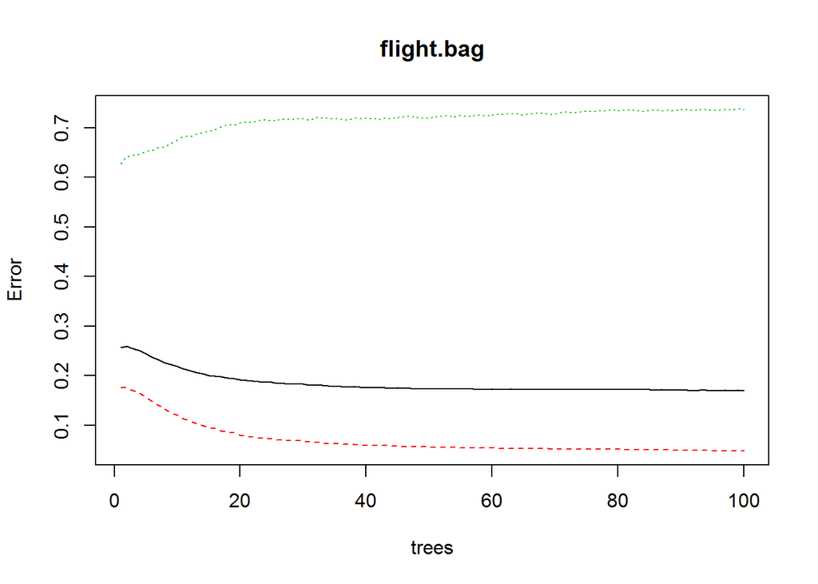

```r
#plot
plot(flight.bag)
```

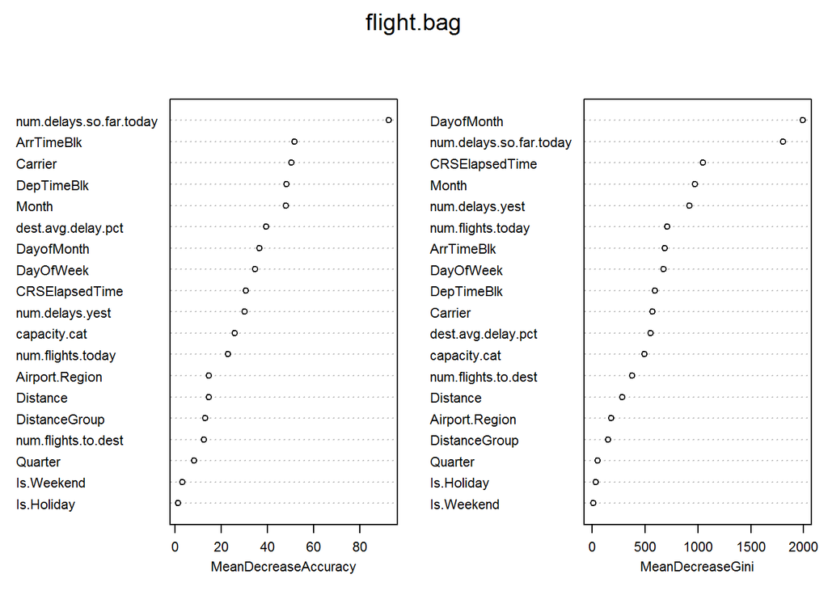

```r
#summary(flight.bag)
varImpPlot(flight.bag, cex=0.7)
```

```r
importance(flight.bag)
```

```
##                                 0           1 MeanDecreaseAccuracy
## DepTimeBlk              54.239959 -54.4852947            48.260212
## Carrier                 43.840766   7.7750813            50.303881
## Quarter                  9.852506  -1.8554739             8.196949
## Month                   52.451299  -0.9013259            47.931846
## DayofMonth              39.604443   1.2973906            36.450330
## DayOfWeek               32.745097   2.6241142            34.669343
## Distance                13.043152   3.0547236            14.626792
## DistanceGroup           11.188512   4.2368948            13.029508
## CRSElapsedTime          29.759720  -2.1295438            30.753370
## ArrTimeBlk              58.066998 -49.1346259            51.821690
## capacity.cat            17.238141  15.7470427            25.782799
## Is.Holiday               1.535516   0.1543598             1.457619
## Is.Weekend               3.092891   0.4117156             3.298874
## num.flights.to.dest     12.581904  -0.4956763            12.449709
## dest.avg.delay.pct      37.794100   7.6679232            39.519619
## Airport.Region          14.204485   0.8828172            14.653644
## num.delays.so.far.today 86.524530   7.1464179            92.507617
## num.delays.yest         32.316257  -0.7326068            30.292920
## num.flights.today       22.868584   2.2003766            23.036559
##                         MeanDecreaseGini
## DepTimeBlk                    592.384600
## Carrier                       571.923044
## Quarter                        53.019103
## Month                         973.187025
## DayofMonth                   1991.748138
## DayOfWeek                     677.091645
## Distance                      281.374720
## DistanceGroup                 149.326374
## CRSElapsedTime               1049.457443
## ArrTimeBlk                    684.017993
## capacity.cat                  492.888034
## Is.Holiday                     32.783394
## Is.Weekend                      8.504397
## num.flights.to.dest           377.642812
## dest.avg.delay.pct            550.312253
## Airport.Region                178.425316
## num.delays.so.far.today      1807.150081
## num.delays.yest               917.633969
## num.flights.today             707.045450
```

Based on the plot of flight.bag, we choose ntree of 100.

Variable importance plot shows that the most important variables are: num.delays.so.far.today, DayofMonth The next most important variables are: DepTimeBlk, Carrier, Month, num.delays.yest, DayOfWeek, CRSElapsedTime, num.delays.yest

## Boosting

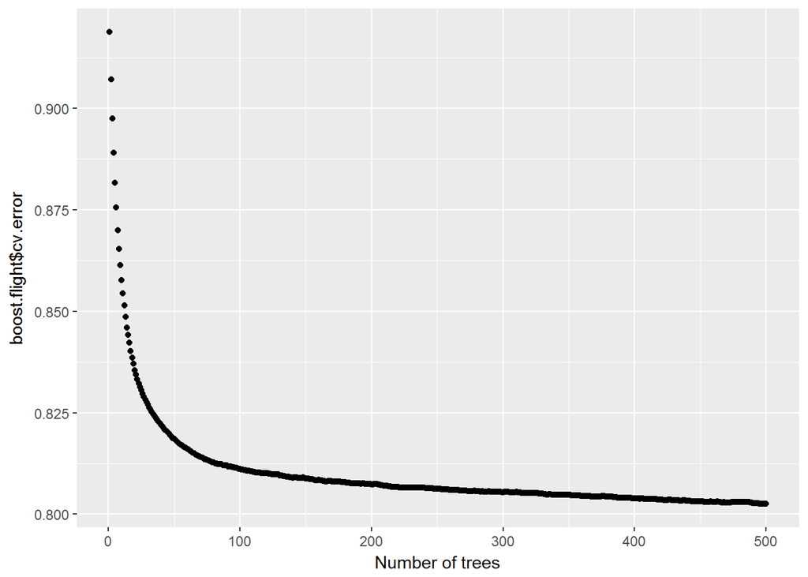

```r
#run boosting. (takes ~5 minutes for n.trees=1000)
boost.flight <- gbm(as.numeric(flight.train$DepDel15 == 1) ~ ., data=flight.train, distribution ="bernoulli", n.trees=500, interaction.depth = 2,verbose=F, shrinkage = 0.1, cv.folds=10)

#show CV error by number of trees
qplot(1:500, boost.flight$cv.error, xlab = "Number of trees")
```

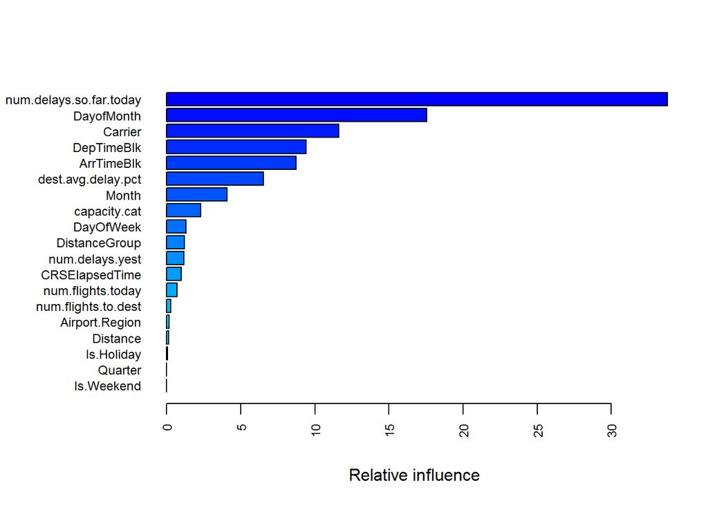

```
##                                             var     rel.inf
## num.delays.so.far.today num.delays.so.far.today 33.78223669
## DayofMonth                           DayofMonth 17.54850165
## Carrier                                 Carrier 11.60999083
## DepTimeBlk                           DepTimeBlk  9.42270720
## ArrTimeBlk                           ArrTimeBlk  8.72171943
## dest.avg.delay.pct           dest.avg.delay.pct  6.54755880
## Month                                     Month  4.06524096
## capacity.cat                       capacity.cat  2.29463397
## DayOfWeek                             DayOfWeek  1.29040205
## DistanceGroup                     DistanceGroup  1.21760100
## num.delays.yest                 num.delays.yest  1.17215746
## CRSElapsedTime                   CRSElapsedTime  0.99370525
## num.flights.today             num.flights.today  0.70270035
## num.flights.to.dest         num.flights.to.dest  0.27639288
## Airport.Region                   Airport.Region  0.15664658
## Distance                               Distance  0.13043785
## Is.Holiday                           Is.Holiday  0.06736705
## Quarter                                 Quarter  0.00000000
## Is.Weekend                           Is.Weekend  0.00000000
```

```r
#variable importance plot. barplot options based on http://statmethods.net/graphs/bar.html
par(las=2, mar=c(5,8,4,2), cex.axis = 0.75)
summary(boost.flight)
```

Based on CV error, 500 trees appears to be sufficient.

The most important variables are: num.delays.so.far.today, DayOfMonth, Carrier, ArrTimeBlk, and DepTimeBlk.

## ROC and Model Statistics

Compare ROC curves across the different methods we used

```r
#get predictions
y.prob.lasso = predict(flight.lasso, s=flight.lasso.cv$lambda.1se, newx = flight.test.pred, type="response")[,1]
y.prob.tree <- predict(flight.tree,flight.test,type="vector")[,2]
y.prob.rf <- predict(flight.rf,flight.test,type="prob")[,2]
y.prob.bag <- predict(flight.bag,newdata=flight.test,type="prob")[,2]
y.prob.boost <- predict(boost.flight,flight.test,type="response")
```

```
## Using 496 trees...
```

```r
#calculate AUC
auc.row = cbind(
  auc(flight.obs, y.prob.lasso),
  auc(flight.obs, y.prob.tree),
  auc(flight.obs, y.prob.bag),
  auc(flight.obs, y.prob.rf),
  auc(flight.obs, y.prob.boost)
)
colnames(auc.row) = c('Lasso','Tree','Random Forest','Bagging','Boosting')
rownames(auc.row) = 'AUC'
```

Print out final metrics to compare the various methods

```r
#cutoffs
alpha.lasso <- 0.4
alpha.tree <- 0.2
alpha.rf <- 0.5
alpha.bag <- 0.5
alpha.boost <- 0.35

#show confusion matrices
#lasso
classMetrics(y.prob.lasso,flight.obs,alpha.lasso, type = "all")$conf.mat
```

```
##          observed
## predicted    0    1
##         0 4714  850
##         1  185  182
```

```r
#tree
classMetrics(y.prob.tree,flight.obs,alpha.tree, type = "all")$conf.mat
```

```
##          observed
## predicted    0    1
##         0 3726  470
##         1 1173  562
```

```r
#random forest
classMetrics(y.prob.rf,flight.obs,alpha.rf, type = "all")$conf.mat
```

```
##          observed
## predicted    0    1
##         0 4688  749
##         1  211  283
```

```r
#bagging
classMetrics(y.prob.bag,flight.obs,alpha.bag, type = "all")$conf.mat
```

```
##          observed
## predicted    0    1
##         0 4698  798
##         1  201  234
```

```r
#boosting
classMetrics(y.prob.boost,flight.obs,alpha.boost, type = "all")$conf.mat
```

```
##          observed
## predicted    0    1
##         0 4486  699
##         1  413  333
```

```r
#calculate classification accuracy metrics
final.metrics = cbind(
  classMetrics(y.prob.lasso,flight.obs,alpha.lasso, type = "all")$perf,
  classMetrics(y.prob.tree,flight.obs,alpha.tree, type = "all")$perf,
  classMetrics(y.prob.rf,flight.obs,alpha.rf, type = "all")$perf,
  classMetrics(y.prob.bag,flight.obs,alpha.bag, type = "all")$perf,
  classMetrics(y.prob.boost,flight.obs,alpha.boost, type = "all")$perf
)
#name the columns
colnames(final.metrics) = c('Lasso','Tree','Random Forest','Bagging','Boosting')
final.metrics = rbind(final.metrics, auc.row)
#round to 2 decimals
final.metrics = round(final.metrics,2)

final.metrics
```

```
##             Lasso Tree Random Forest Bagging Boosting
## accuracy     0.83 0.72          0.84    0.83     0.81
## sensitivity  0.18 0.54          0.27    0.23     0.32
## specificity  0.96 0.76          0.96    0.96     0.92
## ppv          0.50 0.32          0.57    0.54     0.45
## npv          0.85 0.89          0.86    0.85     0.87
## precision    0.50 0.32          0.57    0.54     0.45
## recall       0.18 0.54          0.27    0.23     0.32
## AUC          0.74 0.67          0.75    0.77     0.75
```

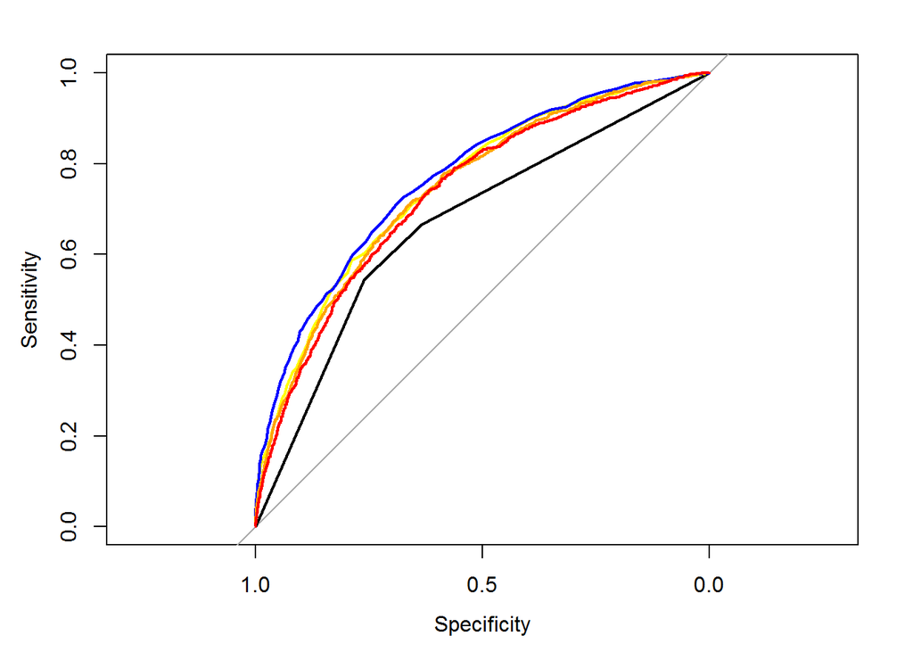

```r
#plot ROC curve
plot.roc(flight.obs, y.prob.tree, col = "black", add=F)
plot.roc(flight.obs, y.prob.bag, col = "yellow", add=T)
plot.roc(flight.obs, y.prob.rf, col = "blue", add=T)
plot.roc(flight.obs, y.prob.boost, col = "orange", add=T)
plot.roc(flight.obs, y.prob.lasso, col = "red", add=T)
```

As we began to think about our model and what performance metrics we cared most about, we realized that False Positives are most costly to us, as they mean predicting a flight is delayed and it is observed to be not delayed, potentially resulting in the person missing their flight.

If our intention is to reduce the overall number of false positives, we care most about getting high specificity in our model. Therefore, we tuned the parameters of each of our models to achieve high levels of specificity. However, there is inherently a trade-off with sensitivity and we found that at the extremes you can trade off a little bit of specificity and get a lot of sensitivity. Therefore, we sought to maintain a moderately high level of specificity (80-90%) while keeping Positive Predicted Value above 50%.

We tested out different cutoff values for each of our models, to see how they performed on specificity, sensitivity, and PPV. We tried to find the best cutoff for each model that resulted in the most satisfactory results for these three metrics.

No cutoff value for lasso and decision tree could enable them to perform well enough on these metrics, and therefore they dropped out of consideration as our model “winners”.

The most common variables across our top three methods (all tree-based) were:

- Month
- DayofMonth
- num.delays.so.far.today
- num.delays.yest
- DepTimeBlk
- Carrier
- DayOfWeek
- CRSElapsedTime (length of flight in minutes)

Of these, we found month and day of month surprising. However, our original graphs did show a marked difference in delays by month. DayOfMonth is harder to understand, but perhaps there are common delay patterns across the months. This would require further analysis.

As for the remaining variables, it seems somewhat intuitive that they would all be highly predictive of delays. We were pleased to see that num.delays.so.far.today, and num.delays.yest, which we had created, were both highly predictive of delays.

Perhaps surprisingly, destination-specific information was not the most predictive. That is, being a destination with high flight volume or high delay rates (such as New York and Chicago) was not the most predictive of a delay.

## Potential future work

If we had more time, we would also investigate the following:

- Handle canceled or diverted flights. These are currently not treated separately in our analysis.
- Bring in daily weather data from an outside source.
- Predict the actual amount of the delay. Right now we only consider this as a classification model. However, once a flight is classified as delayed, we might like to predict how delayed it would be.
- Develop a more sophisticated way to build and evaluate models, based on how late the flight was. In particular, we would like the model to focus on not missing flights that are “very delayed” (eg more than 4 hours). To do this, we might upsample very delayed flights. Additionally, we could evaluate our models by a point system that penalizes the misclassification based on how delayed the flight was.

## 2016 comparison

The project guidelines also recommended that we compare 2006 to 2016 data.

The below plot shows number of flights by by carrier.

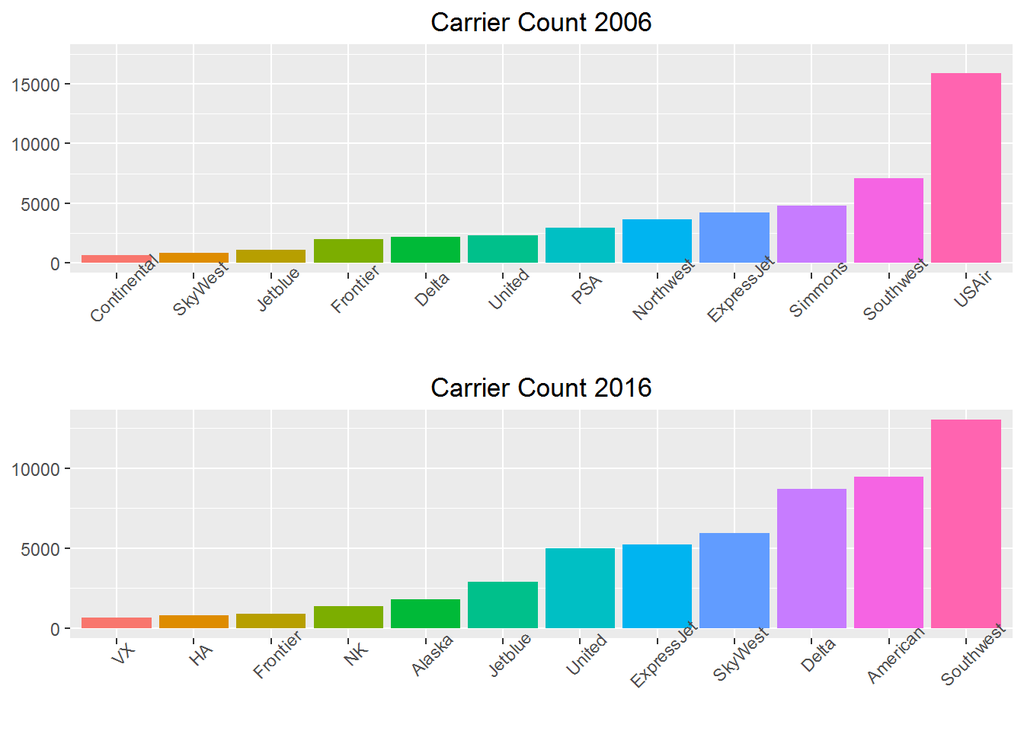

```r
flight.data.plot = ddply(flight.data4, "Carrier", summarise, count.flight = length(Carrier))
flight.data.plot = arrange(flight.data.plot, desc(count.flight))

flight.data.plot1 <- transform(flight.data.plot, Carrier = reorder(Carrier, count.flight))

EDAcarrier.plot <- ggplot(flight.data.plot1, mapping = aes(x = Carrier, y = count.flight, fill = Carrier))

plot1.2006 <-EDAcarrier.plot + geom_bar(stat = "identity") + ggtitle("Carrier Count 2006") + theme(plot.title = element_text(hjust=0.5), axis.text.x = element_text(angle = 45), axis.title.x = element_blank(), axis.title.y = element_blank()) + ylim(0, 17500) + theme(legend.position="none")

#2016 carrier count plot
new.flight.data.plot = ddply(new.flight.data, "carrier", summarise, count.flight = length(carrier)/8)

new.flight.data.plot1 <- transform(new.flight.data.plot, carrier = reorder(carrier, count.flight))

new.carrier.plot <- ggplot(new.flight.data.plot1, mapping = aes(x = carrier, y = count.flight, fill = carrier))

plot.1.2016 <- new.carrier.plot + geom_bar(stat = "identity") + ggtitle("Carrier Count 2016") + theme(plot.title = element_text(hjust=0.5), axis.text.x = element_text(angle = 45), axis.title.x = element_blank(), axis.title.y = element_blank()) + theme(legend.position="none")

#compare 2006 vs. 2016
grid.arrange(plot1.2006, plot.1.2016)
```

In 2006 vs 2016. We notice that only Southwest is in both groups. The other two have changed. USAir left Pittsburgh, and also was later acquired. American and Delta are now the two largest carriers besides Southwest.

U.S. Air was a dominant force at Pittsburgh International Airport in the early 2000’s, but by 2006, had already cut its total flight offering by 50%. Looking at our current data set in comparison to newer data obtained on the Bureau of Transportation website, we notice a substantial shakeup of carriers, routes, capacity, and many other meaningful descriptors in the years 2006-2016. Examining the 2016 flight data for even one month is enough to see that in order to test our analysis we would have to wrangle the new data set so that our model would be amenable to the airline mergers and flow changes at PIT. A true apples-to-apples comparison of the data from 2006 to 2016 (the most current available online) would require deeper wrangling work and could be an interesting project moving forward.